# Overall Objective:

```python
df5=df.loc['20180302 00':'20180303 00']
df5
```

| add_date | object_id | service_code | service_description | service_category | organization_acronym | resolution_date | servicedue_date | service_status | service_request_id | priority | latitude | longitude | zipcode | address_repository_id | ward | details | complete_time |
| --- | --- | --- | --- | --- | --- | --- | --- | --- | --- | --- | --- | --- | --- | --- | --- | --- | --- |
| 2018-03-02 04:51:31 | 369009 | S0459 | Tree Removal | Urban Forrestry | DDOT | 2018-03-02 16:13:11 | 2018-11-09 17:00:00 | CLOSED | 18-00107750 | STANDARD | 38.883046 | -76.941190 | 20019 | 15249 | 7 | 20%e2%80%9d private property tree down blocki... | 0.0 |
| 2018-03-02 05:31:40 | 369010 | S05SL | Streetlight Repair Investigation | Transportation Operations Administration | DDOT | 2018-03-05 20:08:11 | 2018-03-12 16:00:00 | CLOSED | 18-00107752 | STANDARD | 38.960027 | -77.035966 | 20011 | 256059 | 4 | NaN | 3.0 |
| 2018-03-02 05:40:40 | 369011 | S0261 | Parking Enforcement | PEMA- Parking Enforcement Management Administr... | DPW | 2018-03-02 07:58:03 | 2018-03-02 17:00:00 | CLOSED | 18-00107753 | STANDARD | 38.927492 | -77.054192 | 20008 | 219985 | 3 | DPW Officer issued one ticket for private prop... | 0.0 |
| 2018-03-02 06:48:18 | 369012 | S0031 | Bulk Collection | SWMA- Solid Waste Management Admistration | DPW | 2018-03-14 08:28:02 | 2018-03-21 17:00:00 | CLOSED | 18-00107754 | STANDARD | 38.922915 | -76.953990 | 20018 | 310725 | 5 | cph - Collected – Close SR | 12.0 |
| 2018-03-02 05:59:09 | 369013 | S0457 | Tree Inspection | Urban Forrestry | DDOT | 2018-03-02 07:48:09 | 2018-03-08 17:00:00 | CLOSED | 18-00107756 | STANDARD | 38.937474 | -77.065632 | 20008 | 220718 | 3 | Tree cleared from roadway and is scheduled to ... | 0.0 |
| 2018-03-02 06:14:27 | 369014 | S0459 | Tree Removal | Urban Forrestry | DDOT | 2018-03-02 11:13:20 | 2018-11-09 17:00:00 | CLOSED | 18-00107760 | STANDARD | 38.902247 | -77.054082 | 20037 | 277169 | 2 | TREE DEBRIS WILL BE CLEARED ASAP. THANK YOU F... | 0.0 |
| 2018-03-02 06:15:48 | 369015 | S0457 | Tree Inspection | Urban Forrestry | DDOT | 2018-03-02 09:03:18 | 2018-03-08 17:00:00 | CLOSED | 18-00107761 | STANDARD | 38.939491 | -77.051231 | 20010 | 903320 | 4 | 10%27%27x 30%27 limb down from park down acros... | 0.0 |
| 2018-03-02 06:18:10 | 369016 | S05SL | Streetlight Repair Investigation | Transportation Operations Administration | DDOT | NaT | 2018-03-12 16:00:00 | IN-PROGRESS | 18-00107762 | STANDARD | 38.901620 | -77.040354 | 20006 | 279349 | 2 | NaN | NaN |
| 2018-03-02 06:44:09 | 369017 | S0459 | Tree Removal | Urban Forrestry | DDOT | 2018-03-03 19:53:17 | 2018-11-09 17:00:00 | CLOSED | 18-00107768 | STANDARD | 38.971475 | -77.028245 | 20012 | 253368 | 4 | Your location has been inspected and has been ... | 1.0 |
| 2018-03-02 06:40:56 | 369018 | S0457 | Tree Inspection | Urban Forrestry | DDOT | 2018-03-02 08:48:13 | 2018-03-08 17:00:00 | CLOSED | 18-00107766 | STANDARD | 38.917447 | -77.039384 | 20009 | 241384 | 1 | inspection complete. crew scheduled to remove... | 0.0 |
| 2018-03-02 06:40:06 | 369019 | SIGTRAMA | Traffic Signal Issue | Toa- Trans Sys Mnt | DDOT | 2018-03-03 16:58:15 | 2018-03-05 17:00:00 | CLOSED | 18-00107765 | STANDARD | 38.907961 | -77.006283 | 20002 | 288940 | 6 | Work was completed after a review of a field i... | 1.0 |
| 2018-03-02 06:48:51 | 369020 | S0459 | Tree Removal | Urban Forrestry | DDOT | 2018-03-02 09:03:16 | 2018-11-09 17:00:00 | CLOSED | 18-00107771 | STANDARD | 38.834367 | -77.005583 | 20032 | 30638 | 8 | Two trees down%2c sent to the city%27s in hous... | 0.0 |
| 2018-03-02 07:45:58 | 369021 | S05SL | Streetlight Repair Investigation | Transportation Operations Administration | DDOT | 2018-03-16 22:33:07 | 2018-03-12 17:00:00 | CLOSED | 18-00107769 | STANDARD | 38.910964 | -77.027396 | 20009 | 218252 | 2 | NaN | 14.0 |
| 2018-03-02 06:54:57 | 369022 | SIGNMISS | Roadway Signs | Toa-Trans Sys Mnt-Signs | DDOT | 2018-03-10 10:38:10 | 2018-08-31 16:00:00 | CLOSED | 18-00107773 | STANDARD | 38.924577 | -77.029418 | 20009 | 283963 | 1 | DDOT REPAIRED STOP SIGN PER REQUEST. | 8.0 |
| 2018-03-02 06:50:33 | 369023 | RPP | Residential Parking Permit Violation | PEMA- Parking Enforcement Management Administr... | DPW | 2018-03-02 13:07:26 | 2018-03-02 17:00:00 | CLOSED | 18-00107772 | STANDARD | 38.902003 | -77.060336 | 20007 | 274812 | 2 | DPW Officer observed area and no violation(s) ... | 0.0 |
| 2018-03-02 07:07:53 | 369024 | POWEOUTA | Wire Down/Power Outage | 311- Call Center | OUC | 2018-03-02 07:07:53 | 2018-03-02 17:00:00 | CLOSED | 18-00107800 | STANDARD | 38.890366 | -76.931902 | 20019 | 903549 | 7 | NaN | 0.0 |
| 2018-03-02 05:27:28 | 369329 | S0457 | Tree Inspection | Urban Forrestry | DDOT | 2018-03-02 08:28:19 | 2018-03-08 17:00:00 | CLOSED | 18-00107751 | STANDARD | 38.923871 | -77.066398 | 20392 | 291847 | 3 | Tree has been removed. | 0.0 |
| 2018-03-02 05:50:17 | 369330 | S0459 | Tree Removal | Urban Forrestry | DDOT | 2018-03-02 16:38:15 | 2018-11-09 17:00:00 | CLOSED | 18-00107755 | STANDARD | 38.936159 | -77.108829 | 20016 | 295156 | 3 | This is being cleaned up currently | 0.0 |
| 2018-03-02 06:01:52 | 369331 | RPP | Residential Parking Permit Violation | PEMA- Parking Enforcement Management Administr... | DPW | 2018-03-02 07:52:54 | 2018-03-02 17:00:00 | CLOSED | 18-00107757 | STANDARD | 38.918309 | -77.006128 | 20002 | 72560 | 5 | DPW Officer observed area for RPP; black Nissi... | 0.0 |
| 2018-03-02 07:09:43 | 369332 | S0301 | Pothole | Toa-Street & Bridge Maintenance | DDOT | 2018-03-18 14:43:09 | 2018-03-06 18:00:00 | CLOSED | 18-00107759 | STANDARD | 38.961994 | -77.064936 | 20015 | 262446 | 4 | The pothole(s) at this location have been repa... | 16.0 |
| 2018-03-02 06:05:19 | 369333 | S0459 | Tree Removal | Urban Forrestry | DDOT | 2018-03-02 16:18:19 | 2018-11-09 17:00:00 | CLOSED | 18-00107758 | STANDARD | 38.914275 | -77.018759 | 20001 | 309943 | 6 | NaN | 0.0 |
| 2018-03-02 06:32:46 | 369334 | RPP | Residential Parking Permit Violation | PEMA- Parking Enforcement Management Administr... | DPW | 2018-03-02 17:19:42 | 2018-03-02 17:00:00 | CLOSED | 18-00107764 | STANDARD | 38.909663 | -76.934683 | 20019 | 809958 | 7 | dpw officer issued 1 ticket | 0.0 |
| 2018-03-02 06:31:29 | 369335 | S0261 | Parking Enforcement | PEMA- Parking Enforcement Management Administr... | DPW | 2018-03-02 12:52:14 | 2018-03-02 17:00:00 | CLOSED | 18-00107763 | STANDARD | 38.882996 | -77.014921 | 20024 | 301036 | 6 | DPW Officer observed area and no violation(s) ... | 0.0 |
| 2018-03-02 06:56:20 | 369336 | S0459 | Tree Removal | Urban Forrestry | DDOT | 2018-03-02 16:23:15 | 2018-11-09 17:00:00 | CLOSED | 18-00107776 | STANDARD | 38.912434 | -77.072052 | 20007 | 273326 | 2 | 16%22 PEAR. ALSO SIDEWALK IS BLOCKED. | 0.0 |
| 2018-03-02 06:59:41 | 369337 | S0459 | Tree Removal | Urban Forrestry | DDOT | 2018-03-02 10:58:18 | 2018-11-09 17:00:00 | CLOSED | 18-00107780 | STANDARD | 38.860546 | -76.951308 | 20020 | 30858 | 7 | Private Property trees are the responsibility ... | 0.0 |
| 2018-03-02 06:57:46 | 369338 | S0261 | Parking Enforcement | PEMA- Parking Enforcement Management Administr... | DPW | 2018-03-02 09:07:31 | 2018-03-02 17:00:00 | CLOSED | 18-00107779 | STANDARD | 38.924934 | -77.041121 | 20009 | 235900 | 1 | DPW Officer observed location and issued one ... | 0.0 |
| 2018-03-02 07:56:07 | 369339 | S0031 | Bulk Collection | SWMA- Solid Waste Management Admistration | DPW | 2018-03-14 12:18:06 | 2018-03-21 17:00:00 | CLOSED | 18-00107775 | STANDARD | 38.923046 | -77.002506 | 20002 | 49241 | 5 | cph - Collected – Close SR | 12.0 |
| 2018-03-02 06:59:51 | 369340 | S0321 | Recycling Collection - Missed | SWMA- Solid Waste Management Admistration | DPW | 2018-03-03 13:43:11 | 2018-03-05 17:00:00 | CLOSED | 18-00107783 | STANDARD | 38.978031 | -77.035392 | 20012 | 256193 | 4 | Collect on 3-3-18 by L.Ferguson | 1.0 |
| 2018-03-02 06:55:32 | 369341 | S0031 | Bulk Collection | SWMA- Solid Waste Management Admistration | DPW | 2018-03-09 12:03:00 | 2018-03-21 16:00:00 | CLOSED | 18-00107774 | STANDARD | 38.915146 | -77.036859 | 20009 | 241897 | 2 | mg - Collected – Close SR | 7.0 |
| 2018-03-02 07:03:31 | 369342 | S0457 | Tree Inspection | Urban Forrestry | DDOT | 2018-03-02 11:23:20 | 2018-03-08 17:00:00 | CLOSED | 18-00107793 | STANDARD | 38.904400 | -76.994701 | 20002 | 73404 | 6 | Emergency removal work order has been created.... | 0.0 |
| ... | ... | ... | ... | ... | ... | ... | ... | ... | ... | ... | ... | ... | ... | ... | ... | ... | ... |
| 2018-03-02 21:02:42 | 372925 | S0301 | Pothole | Toa-Street & Bridge Maintenance | DDOT | 2018-03-05 19:43:14 | 2018-03-07 17:00:00 | CLOSED | 18-00110928 | STANDARD | 38.824458 | -77.005914 | 20032 | 147432 | 8 | The pothole(s) at this location have been repa... | 2.0 |
| 2018-03-02 21:05:44 | 372926 | S0261 | Parking Enforcement | PEMA- Parking Enforcement Management Administr... | DPW | 2018-03-02 21:45:36 | 2018-03-05 17:00:00 | CLOSED | 18-00110933 | STANDARD | 38.904977 | -77.040244 | 20036 | 241798 | 2 | dpw observed area issued one ticket per your r... | 0.0 |
| 2018-03-02 21:06:42 | 372927 | S0457 | Tree Inspection | Urban Forrestry | DDOT | 2018-03-05 12:08:34 | 2018-03-09 17:00:00 | CLOSED | 18-00110934 | STANDARD | 38.933484 | -77.072415 | 20016 | 902998 | 3 | WO640581 | 2.0 |
| 2018-03-02 22:31:59 | 372928 | S05SL | Streetlight Repair Investigation | Transportation Operations Administration | DDOT | 2018-03-16 14:58:12 | 2018-03-13 17:00:00 | CLOSED | 18-00110944 | STANDARD | 38.890946 | -76.932658 | 20019 | 75950 | 7 | NaN | 13.0 |
| 2018-03-02 22:41:42 | 372929 | S0311 | Rodent Inspection and Treatment | DOH- Department Of Health | DOH | 2018-03-12 15:20:07 | 2018-03-22 17:00:00 | CLOSED | 18-00110946 | STANDARD | 38.922701 | -76.974392 | 20018 | 46529 | 5 | On 3/7/18 @ 9:38am Ronnie Herrington found no... | 9.0 |
| 2018-03-02 21:40:19 | 372930 | S0261 | Parking Enforcement | PEMA- Parking Enforcement Management Administr... | DPW | 2018-03-03 00:40:30 | 2018-03-05 17:00:00 | CLOSED | 18-00110945 | STANDARD | 38.880375 | -76.927973 | 20019 | 288506 | 7 | dpw officer issued multiple tickets at 10:47pm... | 0.0 |
| 2018-03-02 21:48:53 | 372931 | S05SL | Streetlight Repair Investigation | Transportation Operations Administration | DDOT | 2018-03-03 11:28:22 | 2018-03-13 16:00:00 | CLOSED | 18-00110947 | STANDARD | 38.917396 | -77.041317 | 20009 | 235575 | 1 | NaN | 0.0 |
| 2018-03-02 21:59:50 | 372932 | SIGNMISS | Roadway Signs | Toa-Trans Sys Mnt-Signs | DDOT | NaT | 2018-09-03 16:00:00 | IN-PROGRESS | 18-00110953 | STANDARD | 38.961816 | -77.013907 | 20011 | 244927 | 4 | NaN | NaN |
| 2018-03-02 21:57:08 | 372933 | S0457 | Tree Inspection | Urban Forrestry | DDOT | 2018-03-03 19:33:13 | 2018-03-09 17:00:00 | CLOSED | 18-00110952 | STANDARD | 38.916440 | -77.088705 | 20007 | 906793 | 3 | Tree removal work order created | 0.0 |
| 2018-03-02 22:06:46 | 372934 | EMNPV | Emergency No-Parking Verification | PEMA- Parking Enforcement Management Administr... | DPW | 2018-03-03 01:34:40 | 2018-03-05 17:00:00 | CLOSED | 18-00110961 | STANDARD | 38.926227 | -76.959469 | 20018 | 816694 | 5 | dpw observed that the signs are posted at 1:25... | 0.0 |
| 2018-03-02 22:06:25 | 372935 | S0261 | Parking Enforcement | PEMA- Parking Enforcement Management Administr... | DPW | 2018-03-03 01:04:13 | 2018-03-05 17:00:00 | CLOSED | 18-00110960 | STANDARD | 38.908183 | -77.024524 | 20001 | 297581 | 2 | dpw officer went to location and no vehicle wa... | 0.0 |
| 2018-03-02 22:46:34 | 372936 | SIGTRAMA | Traffic Signal Issue | Toa- Trans Sys Mnt | DDOT | 2018-03-07 10:23:47 | 2018-03-06 17:00:00 | CLOSED | 18-00110969 | STANDARD | 38.932822 | -76.997862 | 20064 | 300821 | 5 | Signal system is now operating according to de... | 4.0 |
| 2018-03-02 23:48:09 | 372937 | S0301 | Pothole | Toa-Street & Bridge Maintenance | DDOT | 2018-03-30 09:43:30 | 2018-03-07 18:00:00 | CLOSED | 18-00110970 | STANDARD | 38.938415 | -77.026951 | 20011 | 225053 | 4 | The pothole(s) at this location have been repa... | 27.0 |
| 2018-03-02 23:17:26 | 372938 | S05SL | Streetlight Repair Investigation | Transportation Operations Administration | DDOT | 2018-03-06 04:08:08 | 2018-03-13 16:00:00 | CLOSED | 18-00110980 | STANDARD | 38.952533 | -77.088919 | 20016 | 267631 | 3 | NaN | 3.0 |
| 2018-03-02 23:15:09 | 372939 | S0406 | Roadway Repair | SIOD | DDOT | NaT | 2019-03-25 16:00:00 | IN-PROGRESS | 18-00110978 | STANDARD | 38.927164 | -77.033861 | 20009 | 277062 | 1 | NaN | NaN |
| 2018-03-02 23:26:00 | 372940 | S0457 | Tree Inspection | Urban Forrestry | DDOT | 2018-03-03 09:53:23 | 2018-03-09 17:00:00 | CLOSED | 18-00110985 | STANDARD | 38.917467 | -77.007134 | 20002 | 902506 | 5 | nothing found | 0.0 |
| 2018-03-02 23:28:00 | 372941 | SIGNMISS | Roadway Signs | Toa-Trans Sys Mnt-Signs | DDOT | NaT | 2018-09-03 16:00:00 | IN-PROGRESS | 18-00110986 | STANDARD | 38.941507 | -77.005872 | 20011 | 904765 | 5 | NaN | NaN |
| 2018-03-02 23:25:38 | 372942 | S0406 | Roadway Repair | SIOD | DDOT | NaT | 2019-03-25 16:00:00 | IN-PROGRESS | 18-00110984 | STANDARD | 38.952533 | -77.088919 | 20016 | 267631 | 3 | NaN | NaN |
| 2018-03-02 23:25:30 | 372943 | EMNPV | Emergency No-Parking Verification | PEMA- Parking Enforcement Management Administr... | DPW | 2018-03-03 20:05:07 | 2018-03-05 17:00:00 | CLOSED | 18-00110983 | STANDARD | 38.924204 | -76.958348 | 20018 | 295140 | 5 | NaN | 0.0 |
| 2018-03-02 23:38:04 | 372944 | S0457 | Tree Inspection | Urban Forrestry | DDOT | 2018-03-03 17:18:19 | 2018-03-09 17:00:00 | CLOSED | 18-00110993 | STANDARD | 38.975960 | -77.019968 | 20012 | 802167 | 4 | NaN | 0.0 |
| 2018-03-02 23:38:16 | 372945 | EMNPV | Emergency No-Parking Verification | PEMA- Parking Enforcement Management Administr... | DPW | 2018-03-03 23:47:13 | 2018-03-05 17:00:00 | CLOSED | 18-00110994 | STANDARD | 38.921858 | -76.949156 | 20018 | 289765 | 5 | dpw officer observed signs are posted by bdg#438 | 1.0 |
| 2018-03-02 23:36:17 | 372946 | S0457 | Tree Inspection | Urban Forrestry | DDOT | 2018-03-05 12:08:33 | 2018-03-09 17:00:00 | CLOSED | 18-00110991 | STANDARD | 38.933283 | -77.071377 | 20016 | 221539 | 3 | WO640581 | 2.0 |
| 2018-03-02 23:37:14 | 372947 | TRUREPOR | TRU Report | Tru-311 | OUC | 2018-03-02 23:48:20 | 2018-03-03 23:37:14 | CLOSED | 18-00110992 | STANDARD | 38.933283 | -77.071377 | 20016 | 221539 | 3 | I20180119915 | 0.0 |
| 2018-03-02 23:46:35 | 372948 | S0457 | Tree Inspection | Urban Forrestry | DDOT | 2018-03-04 13:03:13 | 2018-03-09 17:00:00 | CLOSED | 18-00110998 | STANDARD | 38.924798 | -77.107124 | 20016 | 906211 | 3 | scheduled%0a640061 | 1.0 |
| 2018-03-02 23:45:49 | 372949 | EMNPV | Emergency No-Parking Verification | PEMA- Parking Enforcement Management Administr... | DPW | 2018-03-03 23:50:06 | 2018-03-05 17:00:00 | CLOSED | 18-00110997 | STANDARD | 38.864545 | -76.953357 | 20020 | 145306 | 7 | dpw officer observed signs are posted by bdg#135 | 1.0 |
| 2018-03-02 23:56:34 | 372950 | EMNPV | Emergency No-Parking Verification | PEMA- Parking Enforcement Management Administr... | DPW | 2018-03-03 23:50:48 | 2018-03-05 17:00:00 | CLOSED | 18-00111000 | STANDARD | 38.865073 | -76.952008 | 20020 | 145839 | 7 | dpw officer observed signs are posted by bdg#135 | 0.0 |
| 2018-03-02 23:58:02 | 372951 | EMNPV | Emergency No-Parking Verification | PEMA- Parking Enforcement Management Administr... | DPW | 2018-03-03 00:51:58 | 2018-03-05 17:00:00 | CLOSED | 18-00111001 | STANDARD | 38.865323 | -76.957639 | 20020 | 53138 | 7 | dpw officer arrived to location and no signs w... | 0.0 |
| 2018-03-03 00:09:03 | 372952 | EMNPV | Emergency No-Parking Verification | PEMA- Parking Enforcement Management Administr... | DPW | 2018-03-03 23:52:39 | 2018-03-05 17:00:00 | CLOSED | 18-00111006 | STANDARD | 38.931171 | -76.995956 | 20017 | 16 | 5 | dpw officer observed signs are posted by bdg#135 | 0.0 |
| 2018-03-03 00:07:39 | 372953 | EMNPV | Emergency No-Parking Verification | PEMA- Parking Enforcement Management Administr... | DPW | 2018-03-03 20:05:54 | 2018-03-05 17:00:00 | CLOSED | 18-00111005 | STANDARD | 38.930709 | -76.994747 | 20017 | 309078 | 5 | NaN | 0.0 |
| 2018-03-03 00:38:25 | 372954 | S0457 | Tree Inspection | Urban Forrestry | DDOT | 2018-03-04 13:03:14 | 2018-03-09 17:00:00 | CLOSED | 18-00111013 | STANDARD | 38.926355 | -77.106702 | 20016 | 0 | 3 | NaN | 1.0 |

1451 rows × 17 columns

```
Text(0,0.5,'# of request')
```

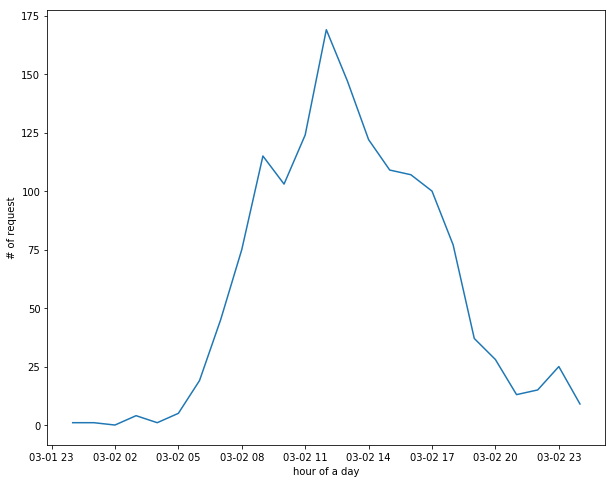

```python
fig = plt.figure(figsize=(10,8))
ax = fig.add_subplot(111)
#ax.xaxis.set_major_locator(days)
#ax.xaxis.set_major_formatter(dfmt)
#ax.xaxis.set_minor_locator(hours)

ax.plot(df5['service_code'].resample('H').count())
#ax.set_ylabel('# of request')
ax.set_xlabel('hour of a day')
ax.set_ylabel('# of request')
```

```python
#days = dates.DayLocator()

#fig = plt.figure(figsize=(20,12))
#ax = fig.add_subplot(111)
#ax.xaxis.set_major_locator(days)
#ax.xaxis.set_major_formatter(dfmt)
#ax.xaxis.set_minor_locator(days)
#
#ax.plot(df['service_code'].resample('D').count())
#ax.set_ylabel('# of request')
#ax.set_xlabel('day of 2018')
#




y=df['service_code'].resample('D').count()
ymax = max(y)


xmax = y[y==ymax]

print(xmax,ymax)


#ax.annotate('local max', xy=(xmax, ymax), xytext=(xmax, ymax+5),
          #  arrowprops=dict(facecolor='black', shrink=0.05),         )

#df['service_code'].resample('D').count()
```

```
add_date
2018-03-02    1442
Freq: D, Name: service_code, dtype: int64 1442
```

```python
df5['service_code'].value_counts()
```

```
S0459         223
S0457         213
SIGNMISS      118
S0031         109
S0261         101
S0011          76
S05SL          75
S0276          65
EMNPV          63
SIGTRAMA       58
S0301          35
S0346          33
S0391          29
RPP            20
S0441          18
EMERPOWE       15
GRAFF          13
TRUREPOR       12
S0311          11
POWEOUTA       11
S0321          11
S0000          10
DMV01          10
11              9
S0406           8
S0181           8
SPSTDAMA        7
S0316           6
S0466           6
S0336           5
             ...
DMV66           5
S0422           4
BICYCLE         4
DCGOVTINFO      4
CONTREMO        3
DMV19           3
S0476           3
S0003           3
DOEEGEC         3
TRACO001        3
PRUNING         3
SIDEWLKEXP      2
FESAADNU        2
S0216           2
S0471           2
S0016           2
DMV51           2
S0046           1
OUTODOR         1
MARKINST        1
DDOCONRU        1
ITISSUES        1
DMV63           1
DMV12           1
RECCONRE        1
DMV48           1
DMVADJSU        1
DMV43           1
DMV37           1
INSECTT01       1
Name: service_code, Length: 62, dtype: int64
```

We can see that on this special day, the top three kinds of service was not what we usually saw. Tree Removal, Tree Inspection and Roadway Signs became the main concern on this day.

What happened on that day? Here is a news "A mighty wind: Behind one of Washington’s worst-ever winter wind storms" https://www.washingtonpost.com/news/capital-weather-gang/wp/2018/03/05/a-mighty-wind-behind-one-of-washingtons-worst-ever-winter-wind-storms-on-march-2/?noredirect=on&utm_term=.6e66f515c812

The wind storm of March 2, 2018, will go down as one of the landmark wintertime wind events in the Washington-Baltimore region. At its height, around 4 p.m. on Friday, there were more than half a million customers without power in the immediate D.C. region. The storm unleashed a relentless hammering on trees, homes, power lines and the frayed psyche of Washingtonians for a very long 18-to-24 hours.

```python
df6=df.loc['20180319 00':'20180320 00']
df6['service_code'].value_counts()
```

```
S0031          216
S0276          159
S0261          145
SIGNMISS        87
S0011           84
S05SL           71
EMNPV           62
S0391           60
S0301           48
S0346           46
S0441           45
RPP             40
GRAFF           33
S0000           23
S0321           22
S0181           21
S0336           19
PRUNING         18
S0457           18
S04TP           17
S0476           14
TRUREPOR        14
S0451           12
DMV01           12
S0361           12
11              11
DMV19           11
CONTREMO        10
S0406            9
S0311            8
              ...
BICYCLE          6
S0316            5
S0466            5
ITISSUES         5
S0003            5
S0016            5
S0459            5
S0216            4
HMDCP            3
SPSTDAMA         3
S0217            3
POWEOUTA         2
S0471            2
FESPEDNU         2
DMVOFFSE         2
SO392            1
S0423            1
S0046            1
DDOCONRU         1
SIDEWLKEXP       1
EMERPOWE         1
DMV66            1
DMV51            1
S0021            1
SNOWREMCOMP      1
RECCONRE         1
S0331            1
DMVADJSU         1
DMV48            1
S0166            1
Name: service_code, Length: 64, dtype: int64
```

```
Text(0,0.5,'# of request')
```

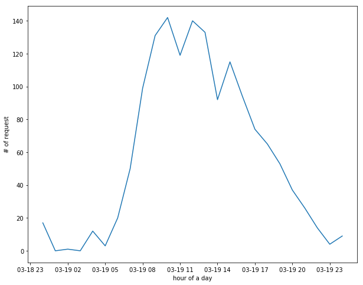

```python
fig = plt.figure(figsize=(10,8))
ax = fig.add_subplot(111)
#ax.xaxis.set_major_locator(days)
#ax.xaxis.set_major_formatter(dfmt)
#ax.xaxis.set_minor_locator(hours)

ax.plot(df6['service_code'].resample('H').count())
#ax.set_ylabel('# of request')
ax.set_xlabel('hour of a day')
ax.set_ylabel('# of request')
```

From the table and plot we can find that the regular categories went up (Bulk Collection, Parking Meter Repair and Parking Enforcement). We look at the calender and find that it may because of the spring break. People were travelling at that time and more people came to visit wahsington DC. So the daily task would be requested more often.